# Dimension reduction

Our goal here is to produce an informative UMAP. To get there, we’ll first use PCA to get a reduced-dimension dataset, and then run UMAP on the leading PCs. If desired, nicer-looking UMAPs can usually be obtained by re-running the UMAP projection under a variety of parameterizations.

We start by loading the data we’ll need, which was output by the earlier scripts from the [workflow vignette](https://github.com/Nanostring-Biostats/CosMx-Analysis-Scratch-Space/tree/Main/_code/vignette):

```r
library(uwot)
library(irlba)
library(viridis)
# load data:
# note these files are for convenience during analysis, and are not a NanoString-supported format
mydir <- "../"
norm <- readRDS(paste0(mydir, "/processed_data/norm.RDS"))
metadata <- readRDS(paste0(mydir, "/processed_data/metadata.RDS"))
```

Now we run PCA and UMAP. For smaller plex studies, UMAP can be run directly on the normalized count data. Good results can be obtained by applying a log transformation, a square root transformation as we’ve done, or no transformation.

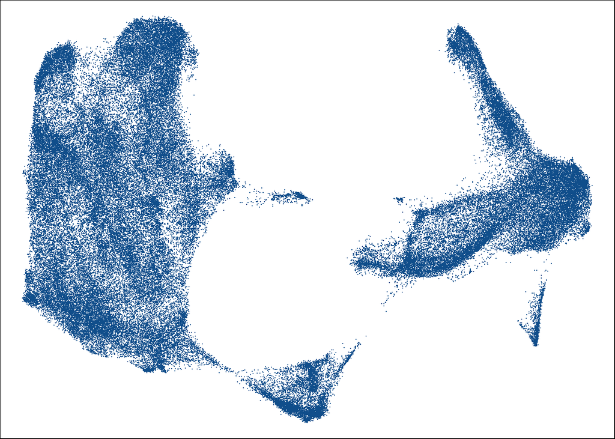

```r
tempumapfileloc <-  paste0(mydir, "/processed_data/um.RDS")
if (!file.exists(tempumapfileloc)) {
  # run PCA:
  pc <- irlba::prcomp_irlba(sqrt(norm), n = 25)$x

  # run UMAP:
  um <- uwot::umap(pc, n_neighbors = 40, spread = 1, min_dist = 0.1, metric = "cosine")
  rownames(um) <- rownames(norm)
  # note: the irlba package is having some version trouble as of early 2024.
  # If you encounter the error message, "function 'as_cholmod_sparse' not provided by package 'Matrix'",
  # then run these lines:
  #  install.packages("Matrix", type = "source")
  #  install.packages("irlba", type = "source")

  # save:
  saveRDS(um, tempumapfileloc)
} else {
  um <- readRDS(tempumapfileloc)
}

# plot it:
par(mar = c(0,0,0,0))
plot(um, pch = 16, cex = 0.1, col = "dodgerblue4")
```

The UMAP projection is useful for data exploration and QC. To begin, it’s worth seeing how important study variables like tissue and slide ID project:

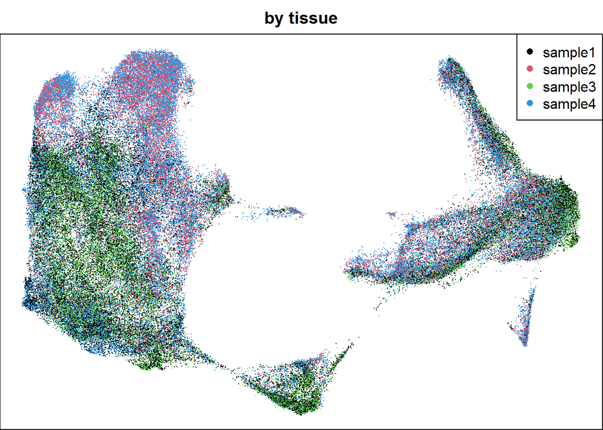

```r
# random point order so no tissue or slide is on top by default:
o <- sample(1:nrow(um))

par(mar = c(0,0,2,0))

# color by tissue
plot(um[o, ], pch = 16, cex = 0.1, col = as.numeric(as.factor(metadata$tissue[o])), main = "by tissue")
legend("topright", pch = 16, col = 1:length(unique(metadata$tissue)), legend = levels(as.factor(metadata$tissue)))
```

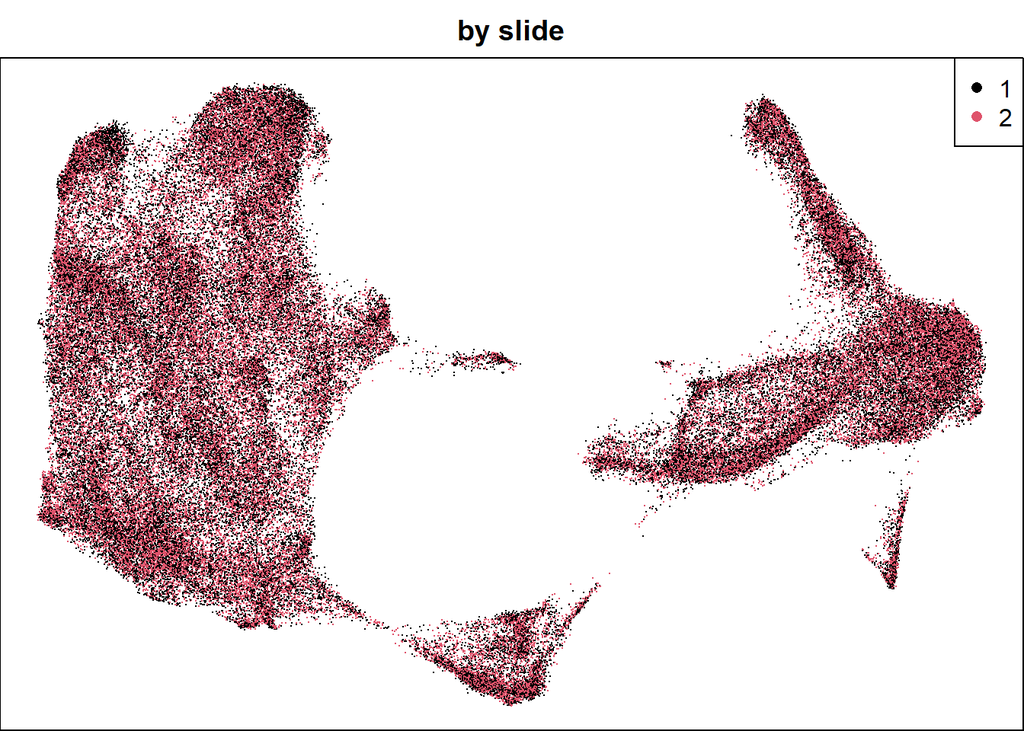

```r
# color by slide ID
plot(um[o, ], pch = 16, cex = 0.1, col = as.numeric(as.factor(metadata$slide_ID[o])), main = "by slide")
legend("topright", pch = 16, col = 1:length(unique(metadata$slide_ID)), legend = levels(as.factor(metadata$slide_ID)))
```

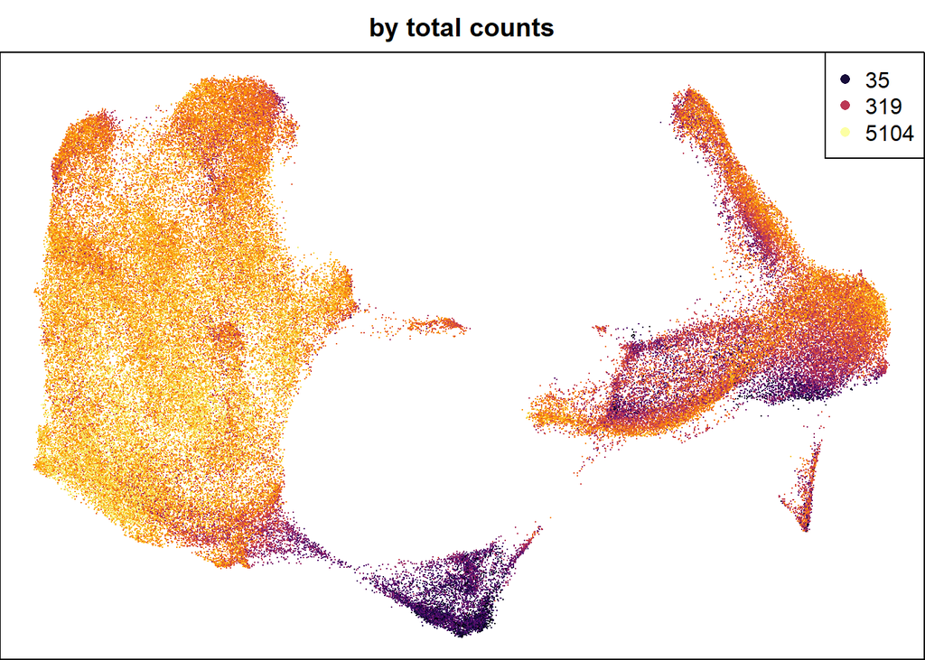

```r
# color by total counts
tempx <- log2(metadata$nCount_RNA)[o]
plot(um[o, ], pch = 16, cex = 0.1, col = viridis_pal(option = "B")(101)[
  pmin(round(1 + 100 * (tempx - min(tempx)) / (quantile(tempx, 0.99) - min(tempx))), 101)],
  main = "by total counts")
legend("topright", pch = 16, col = viridis_pal(option = "B")(101)[c(11,51,101)],
       legend = round(2^c(0.9*min(tempx) + 0.1*quantile(tempx, 0.99), median(c(min(tempx), quantile(tempx, 0.99))), quantile(tempx, 0.99))))
```

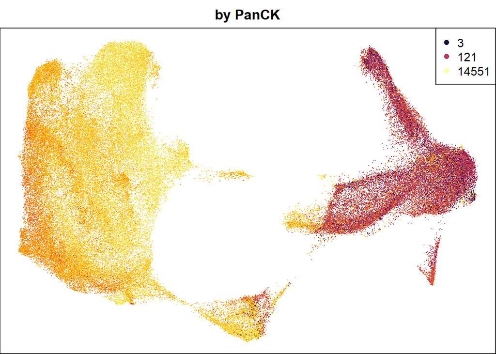

```r
# color by PanCK stain
tempx <- log2(1 + metadata$Mean.PanCK)[o]
plot(um[o, ], pch = 16, cex = 0.1, col = viridis_pal(option = "B")(101)[
  pmin(round(1 + 100 * (tempx - min(tempx)) / (quantile(tempx, 0.99) - min(tempx))), 101)],
  main = "by PanCK")
legend("topright", pch = 16, col = viridis_pal(option = "B")(101)[c(11,51,101)],
       legend = round(2^c(0.9*min(tempx) + 0.1*quantile(tempx, 0.99), median(c(min(tempx), quantile(tempx, 0.99))), quantile(tempx, 0.99))))
```

The above plots show how technical factors influence the data. We see that the two slides overlap nicely, which is reassuring for the absense of batch effects. The PanCK intensity tells us that the island on the left where tissues are separated is probably cancer cells; we will not generally expect cancer cells from different patients to resemble each other.